# Evaluation of Colleges by SAT Scores and Annual Cost

Claudia Cassidy

10/25/2017

#### Introduction

When selecting a college, high school students and their families often try to identify universities which offer the best value for a high quality education. To help find this information, this analysis will use a dataset on data.gov which is maintained by the U.S. Department of Education and provides data about colleges at: https://collegescorecard.ed.gov/data/.

While the dataset contains more than 2,000 fields of data, it is limited in that it seems to only include information about families who have applied for financial aid. It does not include families who earn too much money to qualify for financial aid and thus did not apply, families who would be eligible but did not apply, and international students who would not be eligible to apply for FAFSA.

The data includes information about Federal student loans and grants, but does not include private loans, scholarships or grants. Therefore, data such as the average family income and average tuition paid are likely lower than what the numbers actually are since families with very high incomes would not have applied for financial aid. According to CNN Money (http://time.com/money/4520236/college-financial-aid-why-students-dont-apply/), about 80% of college students apply for financial aid.

As noted in the Data Documentation (https://collegescorecard.ed.gov/data/documentation/): “many elements are available only for Title IV recipients, or students who receive federal grants and loans.”

### The Process: Data Cleaning and Selection

The following analysis focuses on accredited schools, using the most current data from the 2015-16 school year. It groups universities by SAT Scores and then shows how they compare by Annual Cost. I removed data about schools that were not 4 year degree institutions or that were specialty schools. The schools in this analysis are general 4 year public or private colleges.

##### I separated the colleges into three groups:

##### 1 - Schools that rank in the 90th percentile or higher based on SAT scores

##### 2 - Schools within the 75th-90th percentile based on SAT scores

##### 3 - Schools within the 50th-75th percentile based on SAT scores

After cleaning up the data, I wanted to group colleges in a meaningful way. The right fit for a student at a college might be related to many considerations, such as demographics, school size, location in a big city vs. a smaller suburb. Without data about GPA or campus culture, I decided that it might be most useful to group colleges by their SAT scores. Students with similar SAT scores would likely fit in better with other students who had similar scores. For example, if a school’s average SAT scores are much higher than a student’s SAT scores, then the student might find herself lost and stressed at the intensity of the pace of learning.

I considered other ways to evaluate schools for the best student to school match, for example demographics data such as gender, race and family income, but these are highly subjective and cannot indicate a good fit. SAT scores could be used to group students who scored similarly.

Colleges allow students to take the SAT multiple times and will use only the highest SAT scores in each section to get a student’s total SAT score. Therefore, I used the sum of the 75th percentile SAT scores totaled by Math, Reading and Writing categories instead of the SAT Average to get a truer SAT average.

Colleges also consider a student’s Grade Point Average in High School, extra-curricular activities and essay submission when evaluating students. Without this data, this analysis is limited in how accurate it can be in selecting schools that would be a good match. It will, however, help to identify high quality schools that offer lower annual costs.

Note that the SAT scoring has changed as of 2017. The data in this analysis is based on the former scoring system. Conversion of 2017 and beyond scores to the previous scoring system can be found at: https://blog.ivywise.com/blog-0/sat-score-conversion-chart

Note: the analysis includes 4 year bachelor through PhD colleges and universities only.

##### The summary below shows that the highest score for each of the 3 sections: reading, math and writing, is 800. Highest total score for all 3 is 2400. The highest total score for reading and math without writing is 1600.

```
##     Avg SAT       Tot3SAT75      Tot2SAT75       SATVR75
##  Min.   : 708   Min.   :1178   Min.   : 776   Min.   :378
##  1st Qu.: 977   1st Qu.:1600   1st Qu.:1070   1st Qu.:530
##  Median :1044   Median :1710   Median :1140   Median :570
##  Mean   :1063   Mean   :1749   Mean   :1162   Mean   :577
##  3rd Qu.:1126   3rd Qu.:1870   3rd Qu.:1240   3rd Qu.:620
##  Max.   :1544   Max.   :2400   Max.   :1600   Max.   :800
##                 NA's   :488    NA's   :60     NA's   :60
##     SATMT75         SATWR75     Cost Annual    Family Income
##  Min.   :398.0   Min.   :360   Min.   : 7312   Min.   : 17843
##  1st Qu.:540.0   1st Qu.:520   1st Qu.:21445   1st Qu.: 50436
##  Median :570.0   Median :550   Median :32728   Median : 62319
##  Mean   :584.6   Mean   :571   Mean   :33645   Mean   : 65779
##  3rd Qu.:620.0   3rd Qu.:610   3rd Qu.:43270   3rd Qu.: 80548
##  Max.   :800.0   Max.   :800   Max.   :67572   Max.   :149589
##  NA's   :52      NA's   :484
```

##### The 75th percentile of the highest sum of SAT scores is 1870 and the 90th percentile is 2160. The mean is 1749.

### Group 1: Top 10th Percentile Schools as measured by minimum of 90th percentile of the top SAT scores combined: 2160, Orderd by SAT Scores

|  | Name | Tot3SAT75 | Cost Annual | Family Income |
| --- | --- | --- | --- | --- |
| 110404 | California Institute of Technology | 2400 | 60990 | 80002.54 |
| 130794 | Yale University | 2390 | 63970 | 86224.56 |
| 166027 | Harvard University | 2390 | 62250 | 58620.07 |
| 144050 | University of Chicago | 2380 | 67572 | 103014.73 |
| 186131 | Princeton University | 2380 | 59665 | 63688.48 |
| 166683 | Massachusetts Institute of Technology | 2360 | 61030 | 86251.19 |
| 190150 | Columbia University in the City of New York | 2360 | 66604 | 60857.11 |
| 221999 | Vanderbilt University | 2360 | 62320 | 90164.42 |
| 243744 | Stanford University | 2360 | 62363 | 84186.75 |
| 182670 | Dartmouth College | 2340 | 65133 | 88994.52 |
| 217156 | Brown University | 2340 | 62694 | 106820.28 |
| 147767 | Northwestern University | 2330 | 65436 | 102986.91 |
| 168342 | Williams College | 2330 | 64020 | 95346.89 |
| 198419 | Duke University | 2330 | 63999 | 74260.30 |
| 215062 | University of Pennsylvania | 2330 | 64200 | 84604.48 |
| 227757 | Rice University | 2330 | 56316 | 73796.28 |
| 164465 | Amherst College | 2323 | 64006 | 76877.73 |
| 115409 | Harvey Mudd College | 2320 | 66627 | 115901.13 |
| 179867 | Washington University in St Louis | 2320 | 65887 | 122616.27 |
| 121345 | Pomona College | 2300 | 62632 | 67360.66 |
| 162928 | Johns Hopkins University | 2300 | 63509 | 89128.02 |
| 211440 | Carnegie Mellon University | 2300 | 63804 | 110918.11 |
| 212911 | Haverford College | 2300 | 64226 | 101553.85 |
| 112260 | Claremont McKenna College | 2290 | 64215 | 105450.29 |
| 216287 | Swarthmore College | 2290 | 62450 | 84985.32 |
| 110635 | University of California-Berkeley | 2270 | 33993 | 54357.97 |
| 168148 | Tufts University | 2270 | 63358 | 105468.66 |
| 173258 | Carleton College | 2270 | 62465 | 93496.93 |
| 230959 | Middlebury College | 2260 | 61160 | 87785.76 |
| 123961 | University of Southern California | 2250 | 64536 | 80341.72 |
| 167358 | Northeastern University | 2240 | 60179 | 104100.65 |
| 168218 | Wellesley College | 2240 | 61088 | 83918.20 |
| 197133 | Vassar College | 2240 | 63390 | 86361.85 |
| 139755 | Georgia Institute of Technology-Main Campus | 2230 | 24629 | 89378.84 |
| 170976 | University of Michigan-Ann Arbor | 2230 | 26850 | 97203.66 |
| 139658 | Emory University | 2220 | 61344 | 69044.54 |
| 201645 | Case Western Reserve University | 2210 | 59467 | 92196.90 |
| 209922 | Reed College | 2210 | 61795 | 94533.43 |
| 110662 | University of California-Los Angeles | 2200 | 32594 | 53804.34 |
| 164924 | Boston College | 2200 | 62968 | 129669.95 |
| 193900 | New York University | 2200 | 65405 | 86408.92 |
| 234207 | Washington and Lee University | 2200 | 61310 | 138540.22 |
| 161086 | Colby College | 2190 | 61100 | 130447.59 |
| 173902 | Macalester College | 2190 | 59743 | 100087.17 |
| 189097 | Barnard College | 2190 | 63105 | 91044.76 |
| 211273 | Bryn Mawr College | 2190 | 61890 | 93933.40 |
| 165015 | Brandeis University | 2180 | 63222 | 94248.25 |
| 204501 | Oberlin College | 2180 | 64396 | 132824.88 |
| 231624 | College of William and Mary | 2180 | 31175 | 112631.67 |
| 234076 | University of Virginia-Main Campus | 2180 | 27010 | 96898.89 |
| 123165 | Scripps College | 2178 | 63740 | 103902.02 |
| 110680 | University of California-San Diego | 2160 | 30837 | 52686.74 |
| 145637 | University of Illinois at Urbana-Champaign | 2160 | 29568 | 84770.01 |
| 198385 | Davidson College | 2160 | 60921 | 101805.66 |

#### Location of Top 10th Percentile Colleges

##### Click on the map pin to see the school name.

[interactive chart not shown]

#### Summary of the Top 10th percentile colleges.

```
##     Avg SAT       Tot3SAT75      Tot2SAT75       SATVR75
##  Min.   :1305   Min.   :2160   Min.   :1440   Min.   :680.0
##  1st Qu.:1365   1st Qu.:2200   1st Qu.:1470   1st Qu.:730.0
##  Median :1406   Median :2270   Median :1515   Median :750.0
##  Mean   :1417   Mean   :2269   Mean   :1517   Mean   :748.4
##  3rd Qu.:1457   3rd Qu.:2330   3rd Qu.:1558   3rd Qu.:760.0
##  Max.   :1544   Max.   :2400   Max.   :1600   Max.   :800.0
##     SATMT75         SATWR75     Cost Annual    Family Income
##  Min.   :710.0   Min.   :690   Min.   :24629   Min.   : 52687
##  1st Qu.:750.0   1st Qu.:730   1st Qu.:60938   1st Qu.: 83985
##  Median :770.0   Median :755   Median :62458   Median : 90605
##  Mean   :768.7   Mean   :752   Mean   :57947   Mean   : 91787
##  3rd Qu.:790.0   3rd Qu.:770   3rd Qu.:64004   3rd Qu.:103008
##  Max.   :800.0   Max.   :800   Max.   :67572   Max.   :138540
```

#### Average Annual Cost of a top tenth percentile school was $57,947 in 2015.

#### Average of the highest Total SAT scores: 2269

#### Average Family Income of those students who applied for financial aid: $91,787

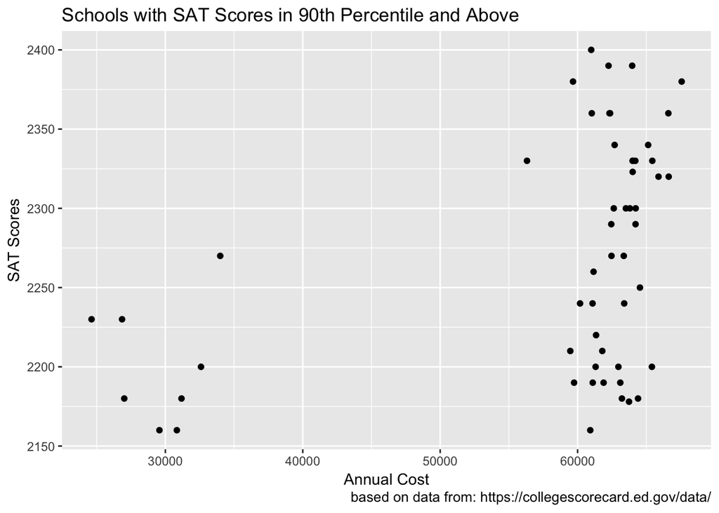

##### CONCLUSION:

It’s expensive to go to most top tenth percentile schools. Most cost around $60,000-70,000 per year but there are several options that offer lower annual cost especially if you qualify for In-State tuition.

#### Top Tenth Percentile Schools Ordered by Annual Cost

|  | Name | Tot3SAT75 | Cost Annual | Family Income |
| --- | --- | --- | --- | --- |
| 144050 | University of Chicago | 2380 | 67572 | 103014.73 |
| 115409 | Harvey Mudd College | 2320 | 66627 | 115901.13 |
| 190150 | Columbia University in the City of New York | 2360 | 66604 | 60857.11 |
| 179867 | Washington University in St Louis | 2320 | 65887 | 122616.27 |
| 147767 | Northwestern University | 2330 | 65436 | 102986.91 |
| 193900 | New York University | 2200 | 65405 | 86408.92 |
| 182670 | Dartmouth College | 2340 | 65133 | 88994.52 |
| 123961 | University of Southern California | 2250 | 64536 | 80341.72 |
| 204501 | Oberlin College | 2180 | 64396 | 132824.88 |
| 212911 | Haverford College | 2300 | 64226 | 101553.85 |
| 112260 | Claremont McKenna College | 2290 | 64215 | 105450.29 |
| 215062 | University of Pennsylvania | 2330 | 64200 | 84604.48 |
| 168342 | Williams College | 2330 | 64020 | 95346.89 |
| 164465 | Amherst College | 2323 | 64006 | 76877.73 |
| 198419 | Duke University | 2330 | 63999 | 74260.30 |
| 130794 | Yale University | 2390 | 63970 | 86224.56 |
| 211440 | Carnegie Mellon University | 2300 | 63804 | 110918.11 |
| 123165 | Scripps College | 2178 | 63740 | 103902.02 |
| 162928 | Johns Hopkins University | 2300 | 63509 | 89128.02 |
| 197133 | Vassar College | 2240 | 63390 | 86361.85 |
| 168148 | Tufts University | 2270 | 63358 | 105468.66 |
| 165015 | Brandeis University | 2180 | 63222 | 94248.25 |
| 189097 | Barnard College | 2190 | 63105 | 91044.76 |
| 164924 | Boston College | 2200 | 62968 | 129669.95 |
| 217156 | Brown University | 2340 | 62694 | 106820.28 |
| 121345 | Pomona College | 2300 | 62632 | 67360.66 |
| 173258 | Carleton College | 2270 | 62465 | 93496.93 |
| 216287 | Swarthmore College | 2290 | 62450 | 84985.32 |
| 243744 | Stanford University | 2360 | 62363 | 84186.75 |
| 221999 | Vanderbilt University | 2360 | 62320 | 90164.42 |
| 166027 | Harvard University | 2390 | 62250 | 58620.07 |
| 211273 | Bryn Mawr College | 2190 | 61890 | 93933.40 |
| 209922 | Reed College | 2210 | 61795 | 94533.43 |
| 139658 | Emory University | 2220 | 61344 | 69044.54 |
| 234207 | Washington and Lee University | 2200 | 61310 | 138540.22 |
| 230959 | Middlebury College | 2260 | 61160 | 87785.76 |
| 161086 | Colby College | 2190 | 61100 | 130447.59 |
| 168218 | Wellesley College | 2240 | 61088 | 83918.20 |
| 166683 | Massachusetts Institute of Technology | 2360 | 61030 | 86251.19 |
| 110404 | California Institute of Technology | 2400 | 60990 | 80002.54 |
| 198385 | Davidson College | 2160 | 60921 | 101805.66 |
| 167358 | Northeastern University | 2240 | 60179 | 104100.65 |
| 173902 | Macalester College | 2190 | 59743 | 100087.17 |
| 186131 | Princeton University | 2380 | 59665 | 63688.48 |
| 201645 | Case Western Reserve University | 2210 | 59467 | 92196.90 |
| 227757 | Rice University | 2330 | 56316 | 73796.28 |
| 110635 | University of California-Berkeley | 2270 | 33993 | 54357.97 |
| 110662 | University of California-Los Angeles | 2200 | 32594 | 53804.34 |
| 231624 | College of William and Mary | 2180 | 31175 | 112631.67 |
| 110680 | University of California-San Diego | 2160 | 30837 | 52686.74 |
| 145637 | University of Illinois at Urbana-Champaign | 2160 | 29568 | 84770.01 |
| 234076 | University of Virginia-Main Campus | 2180 | 27010 | 96898.89 |
| 170976 | University of Michigan-Ann Arbor | 2230 | 26850 | 97203.66 |
| 139755 | Georgia Institute of Technology-Main Campus | 2230 | 24629 | 89378.84 |

These are the top tenth percentile schools ranked by annual cost. Public Universities at In State Tuition rates cost about half of private schools while requiring similar SAT scores.

### Group 2: Colleges as measured by 75th - 90th percentile of the top SAT scores where the combined scores are between 1870 and 2160

|  | Name | Tot3SAT75 | Cost Annual | Family Income |
| --- | --- | --- | --- | --- |
| 203535 | Kenyon College | 2140 | 62160 | 122673.24 |
| 160755 | Tulane University of Louisiana | 2130 | 62856 | 98143.93 |
| 174066 | University of Minnesota-Twin Cities | 2130 | 24823 | 86275.21 |
| 199120 | University of North Carolina at Chapel Hill | 2130 | 23940 | 79797.67 |
| 233374 | University of Richmond | 2120 | 59569 | 94688.38 |
| 237057 | Whitman College | 2120 | 58228 | 114423.69 |
| 149781 | Wheaton College | 2110 | 43715 | 105146.16 |
| 164988 | Boston University | 2100 | 63588 | 105573.07 |
| 228246 | Southern Methodist University | 2100 | 63364 | 107754.26 |
| 228778 | The University of Texas at Austin | 2100 | 26119 | 74066.44 |
| 240444 | University of Wisconsin-Madison | 2100 | 24315 | 103404.77 |
| 216597 | Villanova University | 2090 | 60556 | 130461.76 |
| 124292 | Thomas Aquinas College | 2080 | 35706 | 99704.54 |
| 131469 | George Washington University | 2080 | 63159 | 105773.86 |
| 211291 | Bucknell University | 2080 | 63040 | 129447.03 |
| 120254 | Occidental College | 2070 | 64804 | 96036.73 |
| 126775 | Colorado School of Mines | 2070 | 30990 | 101298.66 |
| 135726 | University of Miami | 2070 | 61666 | 96081.77 |
| 213385 | Lafayette College | 2070 | 61905 | 149588.61 |
| 196079 | SUNY at Binghamton | 2053 | 23480 | 79298.10 |
| 204796 | Ohio State University-Main Campus | 2050 | 25306 | 77577.24 |
| 262129 | New College of Florida | 2050 | 20004 | 63559.50 |
| 145646 | Illinois Wesleyan University | 2040 | 52548 | 113055.83 |
| 196097 | Stony Brook University | 2040 | 22000 | 62477.80 |
| 191241 | Fordham University | 2030 | 60867 | 125462.25 |
| 197708 | Yeshiva University | 2030 | 56555 | 97914.52 |
| 399911 | Soka University of America | 2030 | 44550 | 55530.39 |
| 134130 | University of Florida | 2020 | 20467 | 54908.94 |
| 215293 | University of Pittsburgh-Pittsburgh Campus | 2020 | 32754 | 93236.99 |
| 228787 | The University of Texas at Dallas | 2020 | 23133 | 51393.09 |

[output cut: 78 more lines]

##### Click on a map pin to see the school name.

[interactive chart not shown]

##### Schools in the 75-90th percentile as ranked by the sum of the three highest SAT scores

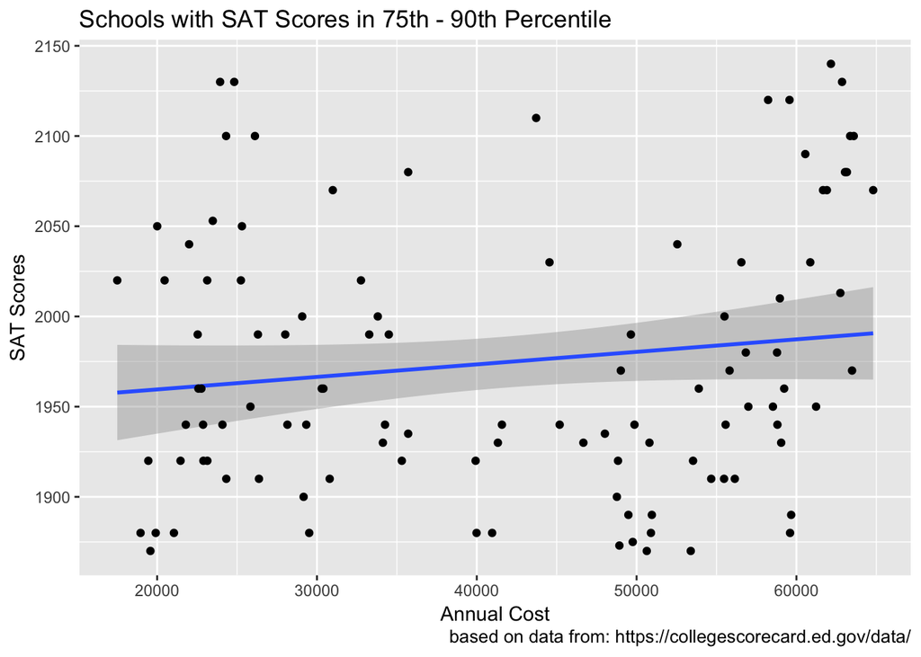

##### CONCLUSION:

In the 75-90th percentile, there is a wide range of costs and seemingly no correlation between annual cost and SAT scores.

### Top 75th - 90th Percentile Schools, Ordered by Annual Cost

|  | Name | Tot3SAT75 | Cost Annual | Family Income |
| --- | --- | --- | --- | --- |
| 230038 | Brigham Young University-Provo | 2020 | 17504 | 57623.56 |
| 180461 | Montana State University | 1880 | 18961 | 69548.09 |
| 230764 | University of Utah | 1920 | 19447 | 51061.42 |
| 137351 | University of South Florida-Main Campus | 1870 | 19578 | 48190.07 |
| 132903 | University of Central Florida | 1880 | 19911 | 46454.55 |
| 262129 | New College of Florida | 2050 | 20004 | 63559.50 |
| 134130 | University of Florida | 2020 | 20467 | 54908.94 |
| 199218 | University of North Carolina Wilmington | 1880 | 21050 | 69080.00 |
| 134097 | Florida State University | 1920 | 21463 | 65105.75 |
| 178411 | Missouri University of Science and Technology | 1940 | 21793 | 75714.08 |
| 196097 | Stony Brook University | 2040 | 22000 | 62477.80 |
| 139959 | University of Georgia | 1990 | 22536 | 81422.10 |
| 243780 | Purdue University-Main Campus | 1960 | 22581 | 91660.97 |
| 199193 | North Carolina State University at Raleigh | 1960 | 22767 | 78488.38 |
| 163268 | University of Maryland-Baltimore County | 1940 | 22873 | 66175.31 |
| 228723 | Texas A & M University-College Station | 1920 | 22893 | 75776.42 |
| 228787 | The University of Texas at Dallas | 2020 | 23133 | 51393.09 |
| 174251 | University of Minnesota-Morris | 1920 | 23141 | 69668.72 |
| 196079 | SUNY at Binghamton | 2053 | 23480 | 79298.10 |
| 199120 | University of North Carolina at Chapel Hill | 2130 | 23940 | 79797.67 |
| 130943 | University of Delaware | 1940 | 24086 | 122411.46 |
| 240444 | University of Wisconsin-Madison | 2100 | 24315 | 103404.77 |
| 151351 | Indiana University-Bloomington | 1910 | 24326 | 95400.12 |
| 174066 | University of Minnesota-Twin Cities | 2130 | 24823 | 86275.21 |
| 236948 | University of Washington-Seattle Campus | 2020 | 25240 | 57388.95 |
| 204796 | Ohio State University-Main Campus | 2050 | 25306 | 77577.24 |
| 233921 | Virginia Polytechnic Institute and State University | 1950 | 25837 | 100847.20 |
| 228778 | The University of Texas at Austin | 2100 | 26119 | 74066.44 |
| 171128 | Michigan Technological University | 1990 | 26306 | 83956.09 |
| 201885 | University of Cincinnati-Main Campus | 1910 | 26370 | 67618.72 |
| 129020 | University of Connecticut | 1990 | 28016 | 87047.28 |
| 185828 | New Jersey Institute of Technology | 1940 | 28150 | 56321.92 |
| 186380 | Rutgers University-New Brunswick | 2000 | 29076 | 64200.55 |
| 100858 | Auburn University | 1900 | 29164 | 88987.81 |
| 231174 | University of Vermont | 1940 | 29332 | 107398.51 |
| 144971 | Eureka College | 1880 | 29515 | 65492.13 |
| 187134 | The College of New Jersey | 1960 | 30299 | 107741.09 |
| 218441 | North Greenville University | 1960 | 30403 | 58410.09 |
| 110653 | University of California-Irvine | 1910 | 30796 | 48494.66 |
| 126775 | Colorado School of Mines | 2070 | 30990 | 101298.66 |
| 215293 | University of Pittsburgh-Pittsburgh Campus | 2020 | 32754 | 93236.99 |
| 110644 | University of California-Davis | 1990 | 33271 | 50549.67 |
| 173142 | Bethany Lutheran College | 2000 | 33807 | 71053.70 |
| 110714 | University of California-Santa Cruz | 1930 | 34124 | 57985.70 |
| 214777 | Pennsylvania State University-Main Campus | 1940 | 34258 | 80547.64 |
| 110705 | University of California-Santa Barbara | 1990 | 34496 | 55149.87 |
| 201654 | Cedarville University | 1920 | 35309 | 84764.17 |
| 107141 | John Brown University | 1935 | 35706 | 64665.35 |
| 124292 | Thomas Aquinas College | 2080 | 35706 | 99704.54 |
| 153250 | Dordt College | 1920 | 39928 | 94154.28 |
| 226231 | LeTourneau University | 1880 | 39986 | 57221.41 |
| 152530 | Taylor University | 1880 | 40960 | 86388.13 |
| 139393 | Covenant College | 1930 | 41320 | 85991.37 |
| 443410 | DigiPen Institute of Technology | 1940 | 41573 | 76656.56 |

### Summary of Schools in the 75th - 90th Percentiles based on SAT Scores

```
##     Avg SAT       Tot3SAT75      Tot2SAT75       SATVR75
##  Min.   :1033   Min.   :1870   Min.   :1230   Min.   :600.0
##  1st Qu.:1188   1st Qu.:1920   1st Qu.:1290   1st Qu.:630.0
##  Median :1220   Median :1955   Median :1310   Median :650.0
##  Mean   :1225   Mean   :1975   Mean   :1327   Mean   :656.1
##  3rd Qu.:1266   3rd Qu.:2022   3rd Qu.:1370   3rd Qu.:670.0
##  Max.   :1346   Max.   :2140   Max.   :1440   Max.   :730.0
##     SATMT75         SATWR75       Cost Annual    Family Income
##  Min.   :575.0   Min.   :600.0   Min.   :17504   Min.   : 46455
##  1st Qu.:650.0   1st Qu.:630.0   1st Qu.:26048   1st Qu.: 69034
##  Median :670.0   Median :645.0   Median :42644   Median : 86718
##  Mean   :670.9   Mean   :647.6   Mean   :41664   Mean   : 87285
##  3rd Qu.:700.0   3rd Qu.:662.5   3rd Qu.:56248   3rd Qu.:102951
##  Max.   :750.0   Max.   :720.0   Max.   :64804   Max.   :149589
```

##### CONCLUSION:

In State tuition at Public Universities offers the lowest annual cost. Students who rank in the 75-90th percentile can get a better cost value by going to a public university in their state if that is an option.

##### Average Annual Cost was $41,664 in 2015.

##### Average of the highest Total SAT scores: 1975

##### Average Family Income of those students who applied for financial aid: $87,285

### Group 3: The 50th - 75th percentile schools as measured by the highest SAT scores combined: between 1749 and 1870

|  | Name | Tot3SAT75 | Cost Annual | Family Income |
| --- | --- | --- | --- | --- |
| 168591 | Alma College | 1868 | 46606 | 76933.67 |
| 179894 | Webster University | 1865 | 40119 | 55684.46 |
| 121309 | Point Loma Nazarene University | 1860 | 45457 | 87367.78 |
| 150163 | Butler University | 1860 | 50538 | 120099.16 |
| 156295 | Berea College | 1860 | 34180 | 26941.64 |
| 157085 | University of Kentucky | 1860 | 24738 | 79063.79 |
| 199111 | University of North Carolina at Asheville | 1860 | 19760 | 60253.41 |
| 202480 | University of Dayton | 1860 | 51320 | 129649.39 |
| 230852 | Champlain College | 1860 | 49702 | 83884.22 |
| 154527 | Wartburg College | 1853 | 47387 | 90808.50 |
| 110097 | Biola University | 1850 | 47468 | 77676.58 |
| 139144 | Berry College | 1850 | 43910 | 89119.40 |
| 145600 | University of Illinois at Chicago | 1850 | 25046 | 47070.24 |
| 152673 | Wabash College | 1850 | 48980 | 95103.06 |
| 165936 | Gordon College | 1850 | 46520 | 96159.03 |
| 213996 | Messiah College | 1850 | 43798 | 95298.79 |
| 231712 | Christopher Newport University | 1850 | 26286 | 106437.98 |
| 148487 | Roosevelt University | 1845 | 40660 | 48666.44 |
| 169716 | University of Detroit Mercy | 1844 | 49675 | 62833.00 |
| 110671 | University of California-Riverside | 1840 | 30943 | 49287.72 |
| 123554 | Saint Mary’s College of California | 1840 | 59167 | 96530.64 |
| 168740 | Andrews University | 1840 | 36206 | 62556.53 |
| 171100 | Michigan State University | 1840 | 24976 | 85377.93 |
| 188429 | Adelphi University | 1840 | 45034 | 78107.88 |
| 197869 | Appalachian State University | 1840 | 19359 | 71355.60 |
| 232308 | Hollins University | 1840 | 49184 | 57137.34 |
| 102049 | Samford University | 1830 | 42270 | 100134.75 |
| 134079 | Florida Southern College | 1830 | 42822 | 80768.92 |
| 136172 | University of North Florida | 1830 | 20616 | 52726.76 |
| 139861 | Georgia College and State University | 1830 | 24478 | 87662.15 |

[output cut: 78 more lines]

### Map of Schools in the 50th to 75th Percentile as Ranked by SAT Scores

[interactive chart not shown]

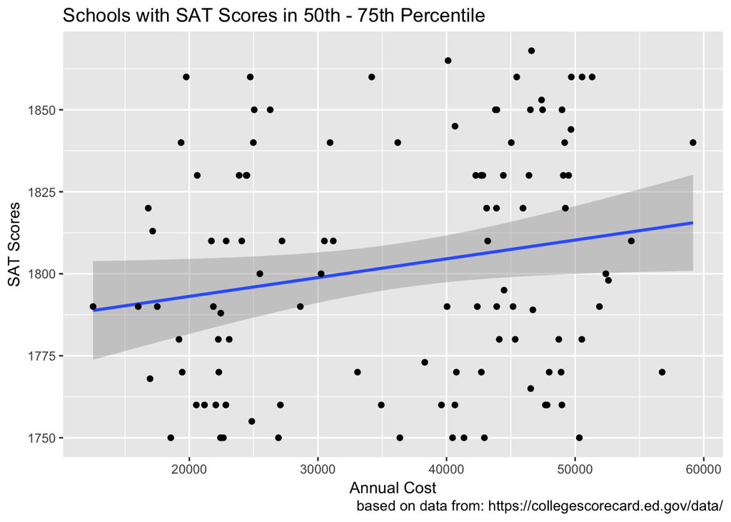

#### The 50-75th percentile schools ordered by Annual Cost:

|  | Name | Tot3SAT75 | Cost Annual | Family Income |
| --- | --- | --- | --- | --- |
| 451671 | University of South Florida-Sarasota-Manatee | 1790 | 12515 | 48190.07 |
| 102614 | University of Alaska Fairbanks | 1790 | 16025 | 47045.83 |
| 180489 | The University of Montana | 1820 | 16807 | 53879.13 |
| 159993 | University of Louisiana at Monroe | 1768 | 16944 | 47736.61 |
| 181394 | University of Nebraska at Omaha | 1813 | 17148 | 60067.57 |
| 180416 | Montana Tech of the University of Montana | 1790 | 17508 | 52720.93 |
| 448840 | University of South Florida-St Petersburg | 1750 | 18556 | 48190.07 |
| 200332 | North Dakota State University-Main Campus | 1780 | 19198 | 84969.64 |
| 197869 | Appalachian State University | 1840 | 19359 | 71355.60 |
| 206604 | Wright State University-Main Campus | 1770 | 19446 | 54689.23 |
| 199111 | University of North Carolina at Asheville | 1860 | 19760 | 60253.41 |
| 182290 | University of Nevada-Reno | 1760 | 20542 | 64103.85 |
| 136172 | University of North Florida | 1830 | 20616 | 52726.76 |
| 141574 | University of Hawaii at Manoa | 1760 | 21177 | 56340.93 |
| 196176 | State University of New York at New Paltz | 1810 | 21716 | 68525.39 |
| 229115 | Texas Tech University | 1790 | 21869 | 71479.98 |
| 206084 | University of Toledo | 1760 | 22057 | 59656.66 |
| 235167 | The Evergreen State College | 1780 | 22253 | 39228.28 |
| 150136 | Ball State University | 1770 | 22294 | 72605.34 |
| 139931 | Georgia Southern University | 1750 | 22424 | 65970.90 |
| 161253 | University of Maine | 1788 | 22444 | 72127.14 |
| 164076 | Towson University | 1750 | 22506 | 77095.16 |
| 196291 | SUNY Maritime College | 1750 | 22648 | 99374.48 |
| 101709 | University of Montevallo | 1760 | 22840 | 51637.79 |
| 237011 | Western Washington University | 1810 | 22864 | 67253.53 |
| 174233 | University of Minnesota-Duluth | 1780 | 23099 | 88656.11 |
| 157289 | University of Louisville | 1830 | 23873 | 64728.09 |
| 232681 | University of Mary Washington | 1810 | 24076 | 89375.32 |
| 209542 | Oregon State University | 1830 | 24418 | 60249.05 |
| 139861 | Georgia College and State University | 1830 | 24478 | 87662.15 |

[output cut: 78 more lines]

```
##     Avg SAT       Tot3SAT75      Tot2SAT75       SATVR75
##  Min.   :1032   Min.   :1750   Min.   :1160   Min.   :558.0
##  1st Qu.:1086   1st Qu.:1770   1st Qu.:1190   1st Qu.:594.5
##  Median :1109   Median :1799   Median :1210   Median :600.0
##  Mean   :1108   Mean   :1802   Mean   :1214   Mean   :606.5
##  3rd Qu.:1128   3rd Qu.:1830   3rd Qu.:1237   3rd Qu.:620.0
##  Max.   :1209   Max.   :1868   Max.   :1320   Max.   :650.0
##     SATMT75         SATWR75       Cost Annual    Family Income
##  Min.   :560.0   Min.   :520.0   Min.   :12515   Min.   : 26942
##  1st Qu.:590.0   1st Qu.:580.0   1st Qu.:24025   1st Qu.: 61981
##  Median :610.0   Median :590.0   Median :40560   Median : 75296
##  Mean   :607.8   Mean   :588.1   Mean   :36230   Mean   : 75629
##  3rd Qu.:620.0   3rd Qu.:600.0   3rd Qu.:46560   3rd Qu.: 87441
##  Max.   :680.0   Max.   :630.0   Max.   :59167   Max.   :142304
```

##### Average Annual Cost was $36,230 in 2015.

##### Average of the highest Total SAT scores: 1802

##### Average Family Income of those students who applied for financial aid: $75,629

#### CONCLUSION:

For the top 10th percentile, there are a handful of public universities with in state tuition costs that are about half as expensive as private schools in this group. For the 75-90th percentile, there are many more choices for lower cost schools with similarly high SAT scores as those that are more expensive. For the 50-75th percentiles, it is a much better value to select an in-state college.

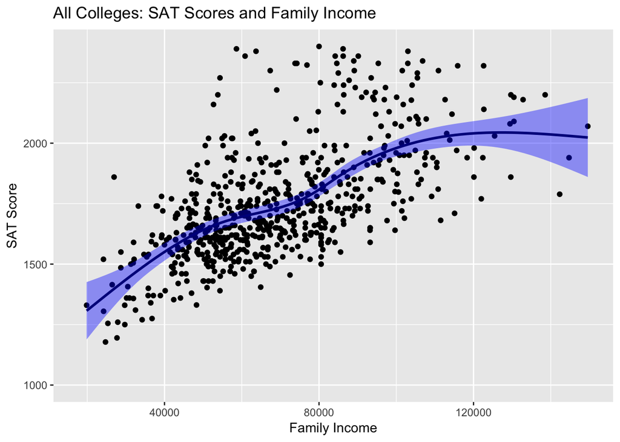

### Correlations:

##### Correlations between SAT Scores and Annual Cost, 50-75th Percentile:

```
## [1] 0.1915272
```

##### Correlations between SAT Scores and Annual Cost, 75-90th Percentile:

```
## [1] 0.1432011
```

##### Correlations between SAT Scores and Annual Cost, 90th Percentile and Above:

```
## [1] 0.4175196
```

##### There is a .41 correlation between SAT Scores and Annual Cost at the top 10th percentile. There is almost no correlation at the 50-75th and 75-90th percentiles.

##### Correlations between SAT Scores and Family Income, All Percentiles:

##### There is a .62 between SAT scores and Family Income

```
## [1] 0.6191821
```

#### CONCLUSION:

From the data it looks like there is a correlation between family income and SAT Scores.Students from families who have a higher average income are more likely to have higher SAT scores. Students who have higher SAT scores are more likely to be admitted into the top 10 percentile of schools.

##### Correlation between Admission Rate and SAT Scores

##### There is a .57 correlation between SAT Scores and Admission rates

```
## [1] 0.5657386
```

### REFLECTIONS

It would be interesting to explore further if there is a causation between Family Income and Admittance Rate into the top colleges. The data shows that there is a correlation between Family Income and High SAT scores and the top 10 percentile of colleges accepts the highest SAT scores. A student from a higher income family is perhaps more likely to have higher SAT scores.

The data further shows that the average family income in the top 10th percentile, $91,787, is higher than the 75-90th percentile, $87,285, which is in turn higher than the family income in the 50-75th percentile, $75,629. Perhaps Family Income determines your future SAT scores and therefore your likelihood of getting into a good college and therefore your chances of getting the best education in order to get the best job and preparation for financial success after graduation.

Since colleges select the highest scores in each category and students are able to retake the SAT as many times as they’d like, it’s possible that students in higher income homes were able to spend more money on SAT preparation courses and to take the exam several times more than students who could not afford to retake the exam and thus improve their scores.

It would also be interesting to find out if families with higher incomes are able to provide better quality education at the K-12 grades which leads to higher SAT scores. Perhaps K-12 schools in wealthier neighborhoods and private schools are better prepared to score higher on the SAT which then leads to more opportunities for these students to get into better colleges.